# Estimating Random Intercept Model in R Part 1

EDUC 7456

Benjamin Shear

## Load Packages

```r
library(tidyverse)
library(haven)
library(vtable)
library(lme4)
library(sjPlot)
library(arm)
library(jtools)
library(insight)
```

## Load Data

In the example here we will use the `popular2.sav` SPSS format dataset from Hox et al. (2018). See Appendix E for discussion of the dataset.

```r
dat_popular <- read_spss(file = "popular2.sav")
head(dat_popular)
```

```
## # A tibble: 6 × 15
##   pupil class extrav sex        texp popular popteach Zextrav   Zsex Ztexp
##   <dbl> <dbl>  <dbl> <dbl+lbl> <dbl>   <dbl>    <dbl>   <dbl>  <dbl> <dbl>
## 1     1     1      5 1 [girl]     24     6.3        6  -0.170  0.989  1.49
## 2     2     1      7 0 [boy]      24     4.9        5   1.41  -1.01   1.49
## 3     3     1      4 1 [girl]     24     5.3        6  -0.962  0.989  1.49
## 4     4     1      3 1 [girl]     24     4.7        5  -1.75   0.989  1.49
## 5     5     1      5 1 [girl]     24     6          6  -0.170  0.989  1.49
## 6     6     1      4 0 [boy]      24     4.7        5  -0.962 -1.01   1.49
## # ℹ 5 more variables: Zpopular <dbl>, Zpopteach <dbl>, Cextrav <dbl>,
## #   Ctexp <dbl>, Csex <dbl>
```

### Convert factor to numeric

The variable `sex` is a labelled variable. This will sometimes prevent the variable from being summarized as a binary indicator variable. Here I create a new indicator (dummy) variable called `female` equal to 1 if a student’s sex is “girl” in the original data and equal to 0 if the student’s sex is “boy”.

```r
dat_popular$female <- ifelse(dat_popular$sex==1,1,0)
```

## Summarize Data

With a multilevel dataset we need to summarize the data at each level of interest to understand the structure.

### Full Dataset

We will use the `sumtable` function from the `vtable` package again to create summary tables. For now we will only ask the function to summarize the following variables:

- pupil
- class
- extrav
- female
- texp
- popular

```r
sumtable(data = dat_popular, vars = c("pupil", "class", "extrav", "female", "texp", "popular"))
```

Summary Statistics

| Variable | N | Mean | Std. Dev. | Min | Pctl. 25 | Pctl. 75 | Max |
| --- | --- | --- | --- | --- | --- | --- | --- |
| pupil | 2000 | 11 | 6 | 1 | 6 | 16 | 26 |
| class | 2000 | 50 | 29 | 1 | 25 | 76 | 100 |
| extrav | 2000 | 5.2 | 1.3 | 1 | 4 | 6 | 10 |
| female | 2000 | 0.51 | 0.5 | 0 | 0 | 1 | 1 |
| texp | 2000 | 14 | 6.6 | 2 | 8 | 20 | 25 |
| popular | 2000 | 5.1 | 1.4 | 0 | 4.1 | 6 | 9.5 |

### Summarize Level-1 Variables

For a summary of level-1 variables we can make the same table, but remove the `class` and `texp` variables, which are technically “level-2” variables. They do not vary across students within the same class.

```r
sumtable(data = dat_popular, vars = c("pupil", "extrav", "female", "popular"))
```

Summary Statistics

| Variable | N | Mean | Std. Dev. | Min | Pctl. 25 | Pctl. 75 | Max |
| --- | --- | --- | --- | --- | --- | --- | --- |
| pupil | 2000 | 11 | 6 | 1 | 6 | 16 | 26 |
| extrav | 2000 | 5.2 | 1.3 | 1 | 4 | 6 | 10 |
| female | 2000 | 0.51 | 0.5 | 0 | 0 | 1 | 1 |
| popular | 2000 | 5.1 | 1.4 | 0 | 4.1 | 6 | 9.5 |

### Calculate Level-2 Variables

At level-2 we want to summarize the `class` variable and the `texp` variable. To facilitate this, we will create a new dataset in R that has only 100 rows - 1 for each class. For the `texp` variable I will calculate the class mean; however, the `texp` variable doesn’t vary within classes so the mean is the same thing as “the” value for that class. I will also ask R to calculate the number of students in each class. Although this is not a variable we will use in the models later, it is very useful information to summarize.

To do the summary, I use the “pipe” operator `%>%` and the `group_by()` and the `summarise()` functions. We will use these often.

```r
level2_data <- dat_popular %>%
  group_by(class) %>%  # group by class ID
  summarise(
    MNtexp = mean(texp), # the MNtexp will be the mean of texp in each class
    Nstu = n(),           # Nstu is the number of rows in each class
    mnpop=mean(popular)
  ) %>% ungroup()
```

### Summarize Level-2 Variables

```r
sumtable(level2_data)
```

Summary Statistics

| Variable | N | Mean | Std. Dev. | Min | Pctl. 25 | Pctl. 75 | Max |
| --- | --- | --- | --- | --- | --- | --- | --- |
| class | 100 | 50 | 29 | 1 | 26 | 75 | 100 |
| MNtexp | 100 | 14 | 6.6 | 2 | 8.8 | 20 | 25 |
| Nstu | 100 | 20 | 2 | 16 | 19 | 21 | 26 |
| mnpop | 100 | 5.1 | 0.87 | 2.6 | 4.4 | 5.6 | 7.3 |

## Empty Random Intercept (RI) Model

The “empty” RI model allows us to estimate the between-class and within-class variance components of the `popular` rating variable. Statistically the model is:

$$popular_{ij}=\gamma_{00}+u_{0j}+e_{ij}$$

$$u_{0j} \sim
N(0,\sigma^2_{u_0})$$

$$e_{ij} \sim N(0,\sigma^2_e)$$

### Make Picture of Empty RI Model

We can make graph to show this model using `ggplot()`:

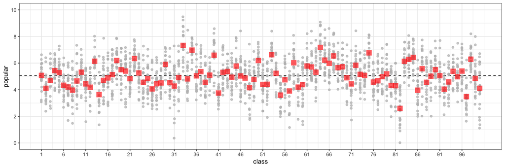

```r
dat_popular %>%
  ggplot(aes(x=class, y=popular)) +
  geom_hline(yintercept = mean(dat_popular$popular), color="black", lty=2) +
  geom_jitter(alpha=0.75, color="grey", width=0.05) +
  stat_summary(
    fun = "mean",
    geom = "point",
    col = "red",
    shape = 15,
    size = 4,
    alpha = 0.65
  ) +
  scale_x_continuous(breaks = seq(1,100,5)) +
  scale_y_continuous(limits = c(0,10), breaks = seq(0,10,2)) +
  theme_bw()
```

### Estimate with lmer()

We estimate the model using `lmer()`.

```r
ri_model <- lmer(popular ~ 1 + (1 | class), data = dat_popular)
```

### Print Results

The simplest way to “see” the results is to use the `summary()` function, although it is a lot of output.

```r
summary(ri_model)
```

```
## Linear mixed model fit by REML ['lmerMod']
## Formula: popular ~ 1 + (1 | class)
##    Data: dat_popular
##
## REML criterion at convergence: 6330.5
##
## Scaled residuals:
##     Min      1Q  Median      3Q     Max
## -3.5655 -0.6975  0.0020  0.6758  3.3175
##
## Random effects:
##  Groups   Name        Variance Std.Dev.
##  class    (Intercept) 0.7021   0.8379
##  Residual             1.2218   1.1053
## Number of obs: 2000, groups:  class, 100
##
## Fixed effects:
##             Estimate Std. Error t value
## (Intercept)  5.07786    0.08739    58.1
```

### How to “get” Variance Components

For now, we are most interested in the variance components. We can have R give those to us in an easier to use way using `VarrCorr()`.

```r
VarCorr(ri_model)
```

```
##  Groups   Name        Std.Dev.
##  class    (Intercept) 0.83792
##  Residual             1.10535
```

Or a slightly more detailed version by converting to a data.frame.

```r
data.frame(VarCorr(ri_model))
```

```
##        grp        var1 var2      vcov     sdcor
## 1    class (Intercept) <NA> 0.7021047 0.8379169
## 2 Residual        <NA> <NA> 1.2217935 1.1053477
```

But we can also use the [insight](https://easystats.github.io/insight/index.html) package functions.

```r
get_variance_intercept(ri_model)
```

```
## var.intercept.class
##           0.7021047
```

```r
get_variance_residual(ri_model)
```

```
## var.residual
##     1.221793
```

### Calculate ICC

We can calculate the ICC as:

$$\hat
{ICC}=\frac{\hat\sigma^2_{u_0}}{\hat\sigma^2_{u_0}+\hat
\sigma^2_e}$$

You could manually calculate this. Using the R objects we can calculate:

Option 1 using `VarCorr()`

```r
varcomps <- data.frame(VarCorr(ri_model))
var_btwn <- varcomps[1,4]
var_wthn <- varcomps[2,4]
(var_btwn)/(var_btwn+var_wthn)
```

```
## [1] 0.3649386
```

Option 2 using `insight` functions

```r
var_btwn <- get_variance_intercept(ri_model)
var_wthn <- get_variance_residual(ri_model)
(var_btwn)/(var_btwn+var_wthn)
```

```
## var.intercept.class
##           0.3649386
```

Option 3: most of the functions below!

## More Ways to Print Results

Here are three useful ways to summarize the results of a `lmer` object. They are useful for different contexts:

- [tab_model()](https://strengejacke.github.io/sjPlot/articles/tab_model_estimates.html) in the `sJPlot` package is great for making nice tables that you could include in a paper. Very customizable, and can be exported to MS Word and Excel.
- [display()](https://rdrr.io/cran/arm/#vignettes) in the `arm` package is useful for a compact, quick summary to look at results that is less messy than the `summary()` function. This is mostly useful for a quick look at a model, for example while doing analysis or in class.
- [summ()](https://jtools.jacob-long.com/articles/summ.html) in the `jtools` package is somewhere in between. It is a bit more detailed and neater than `display()` but it isn’t really “publication-ready” the way `tab_model()` results (almost) are.

### tab_model() in `sjPlot`

Default:

```r
tab_model(ri_model)
```

|  | popularity sociometric score |  |  |
| --- | --- | --- | --- |
| Predictors | Estimates | CI | p |
| (Intercept) | 5.08 | 4.91 – 5.25 | **<0.001** |
| Random Effects |  |  |  |
| σ<sup>2</sup> | 1.22 |  |  |
| τ<sub>00</sub> <sub>class</sub> | 0.70 |  |  |
| ICC | 0.36 |  |  |
| N <sub>class</sub> | 100 |  |  |
| Observations | 2000 |  |  |
| Marginal R<sup>2</sup> / Conditional R<sup>2</sup> | 0.000 / 0.365 |  |  |

Some customization:

```r
tab_model(ri_model,
          dv.labels = "Model Title",
          show.ci=FALSE,
          show.se=TRUE,
          string.se="SE",
          string.est="Est.")
```

|  | Model Title |  |  |
| --- | --- | --- | --- |
| Predictors | Est. | SE | p |
| (Intercept) | 5.08 | 0.09 | **<0.001** |
| Random Effects |  |  |  |
| σ<sup>2</sup> | 1.22 |  |  |
| τ<sub>00</sub> <sub>class</sub> | 0.70 |  |  |
| ICC | 0.36 |  |  |
| N <sub>class</sub> | 100 |  |  |
| Observations | 2000 |  |  |
| Marginal R<sup>2</sup> / Conditional R<sup>2</sup> | 0.000 / 0.365 |  |  |

### display() in `arm`

```r
arm::display(ri_model, digits=3)
```

```
## lmer(formula = popular ~ 1 + (1 | class), data = dat_popular)
## coef.est  coef.se
##    5.078    0.087
##
## Error terms:
##  Groups   Name        Std.Dev.
##  class    (Intercept) 0.838
##  Residual             1.105
## ---
## number of obs: 2000, groups: class, 100
## AIC = 6336.5, DIC = 6324.4
## deviance = 6327.5
```

### summ() in `jtools`

```r
summ(ri_model)
```

| Observations | 2000 |
| --- | --- |
| Dependent variable | popular |
| Type | Mixed effects linear regression |

| AIC | 6336.51 |
| --- | --- |
| BIC | 6353.31 |
| Pseudo-R² (fixed effects) | 0.00 |
| Pseudo-R² (total) | 0.36 |

| Fixed Effects | Fixed Effects Est. | Fixed Effects S.E. | Fixed Effects t val. | Fixed Effects d.f. | Fixed Effects p |
| --- | --- | --- | --- | --- | --- |
| (Intercept) | 5.08 | 0.09 | 58.10 | 98.91 | 0.00 |

p values calculated using Satterthwaite d.f.

| Random Effects Group | Random Effects Parameter | Random Effects Std. Dev. |
| --- | --- | --- |
| class | (Intercept) | 0.84 |
| Residual |  | 1.11 |

| Grouping Variables Group | Grouping Variables # groups | Grouping Variables ICC |
| --- | --- | --- |
| class | 100 | 0.36 |